[figure not shown]

[figure not shown]

Premier League 2020-2021: Matchday 1 (Sep. 12, 2020)

Minute

Team

Player

Result

Shot Map

Cumulative xG

Situation

Shot Type

Assist Player

Assist Action

2

Liverpool

Mohamed Salah

Blocked Shot

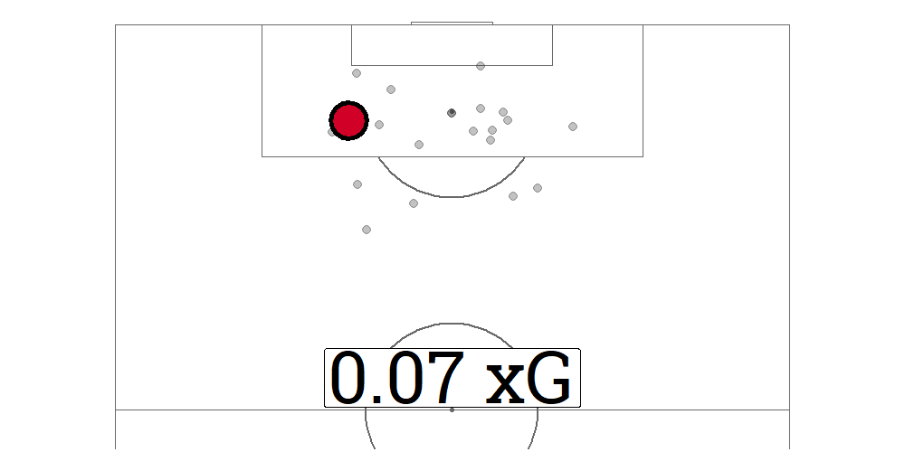

0.06855621

Open Play

Left Foot

Sadio Mané

Pass

3

Liverpool

Mohamed Salah

GOAL ⚽

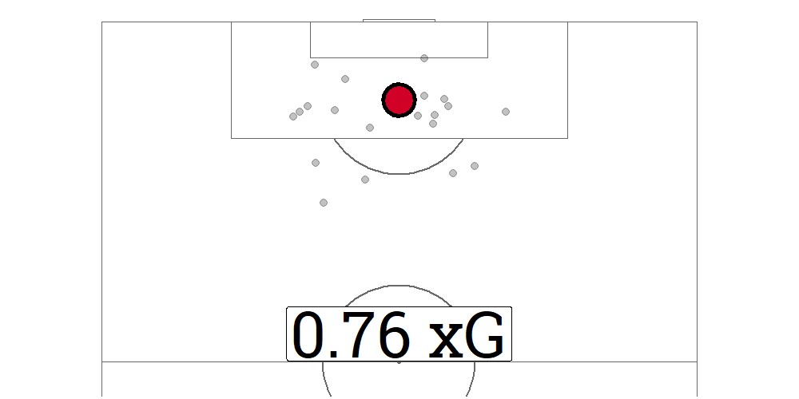

0.82972505

Penalty

Left Foot

6

Liverpool

Mohamed Salah

Blocked Shot

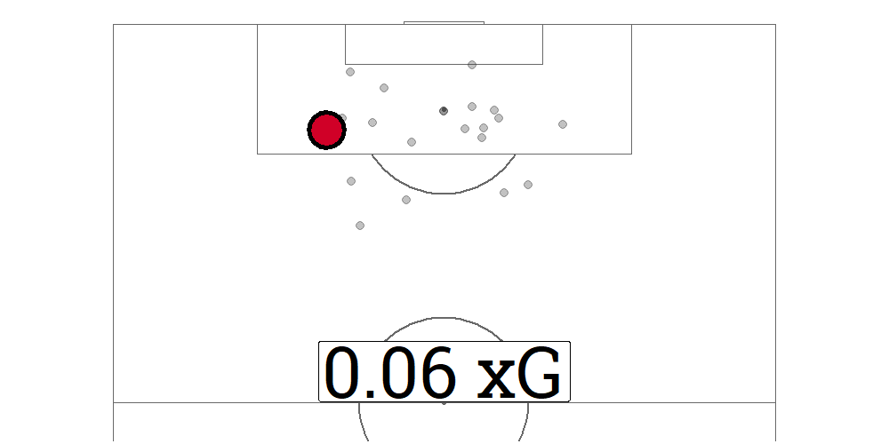

0.89052629

Open Play

Left Foot

Sadio Mané

Pass

11

Leeds

Jack Harrison

GOAL ⚽

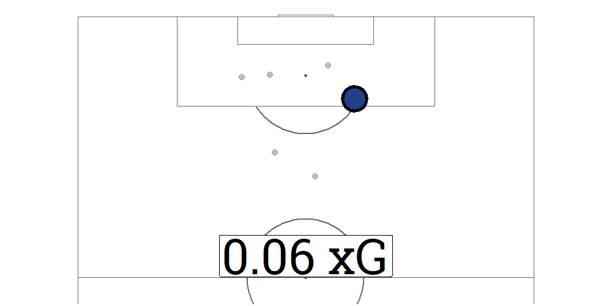

0.05824600

Open Play

Right Foot

Kalvin Phillips

Take On

19

Liverpool

Virgil van Dijk

GOAL ⚽

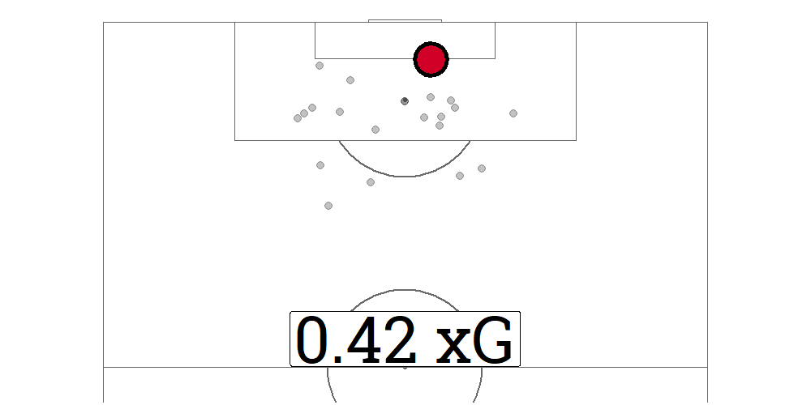

1.30983927

From Corner

Head

Andrew Robertson

Cross

24

Liverpool

Jordan Henderson

Saved Shot

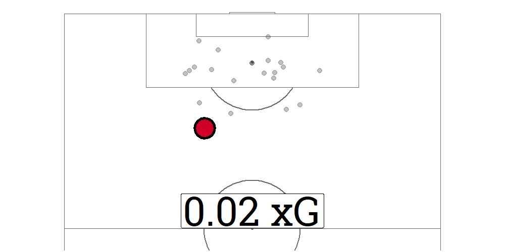

1.32890952

Open Play

Right Foot

28

Liverpool

Naby Keita

Blocked Shot

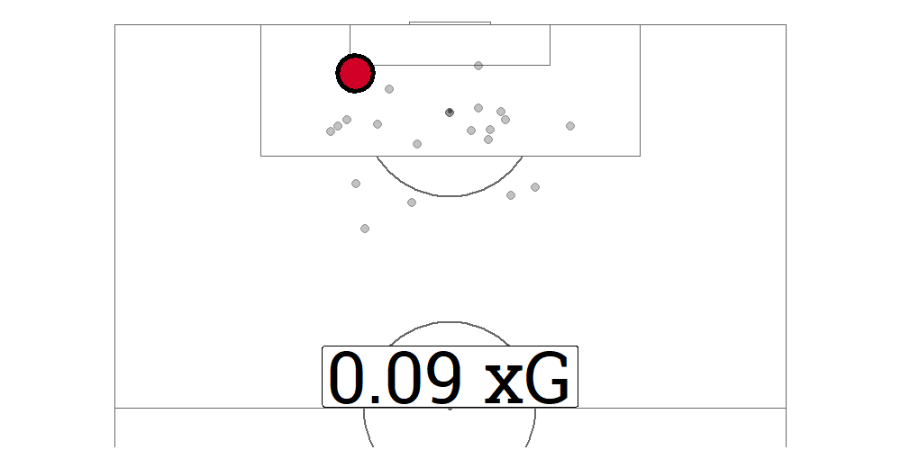

1.42297549

Open Play

Right Foot

29

Leeds

Patrick Bamford

GOAL ⚽

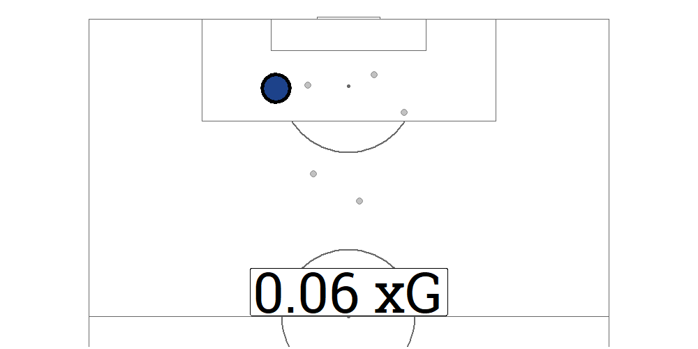

0.11357041

Open Play

Right Foot

32

Liverpool

Mohamed Salah

GOAL ⚽

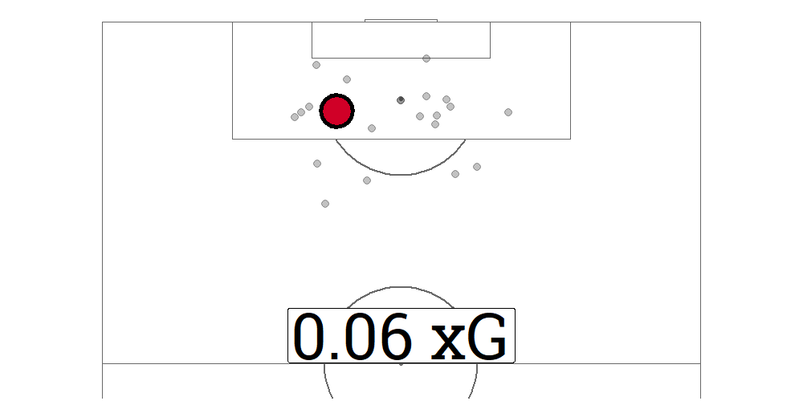

1.48540261

Set Piece

Left Foot

39

Liverpool

Sadio Mané

Blocked Shot

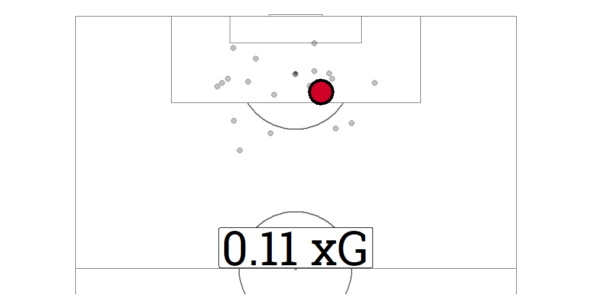

1.59228222

Open Play

Right Foot

Georginio Wijnaldum

Pass

39

Liverpool

Sadio Mané

Blocked Shot

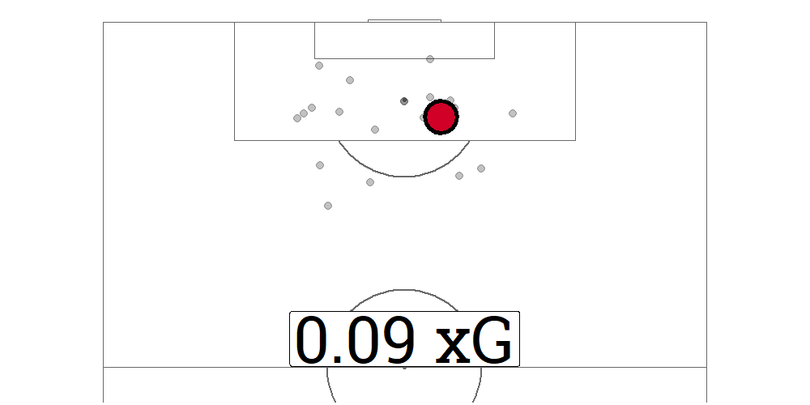

1.68037066

Open Play

Left Foot

Rebound

48

Liverpool

Georginio Wijnaldum

Saved Shot

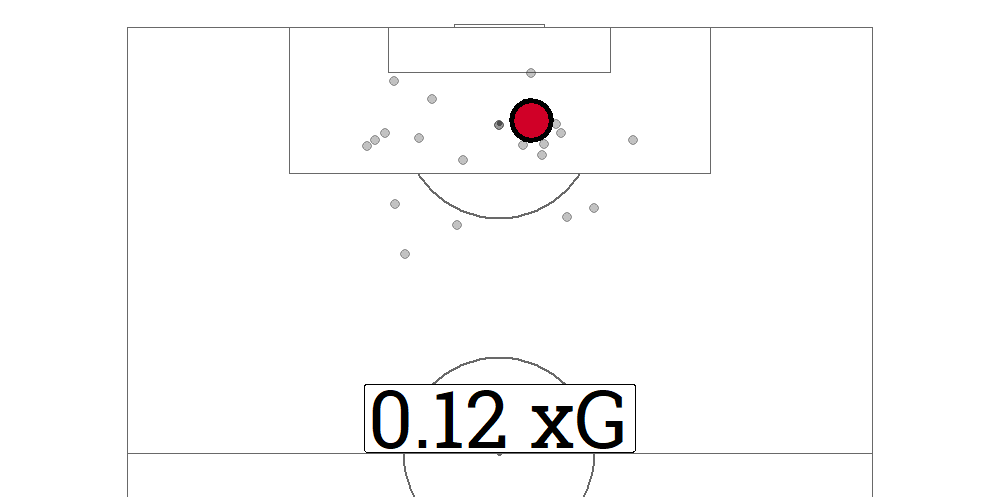

1.80105035

Open Play

Right Foot

Sadio Mané

Ball Touch

49

Leeds

Patrick Bamford

Blocked Shot

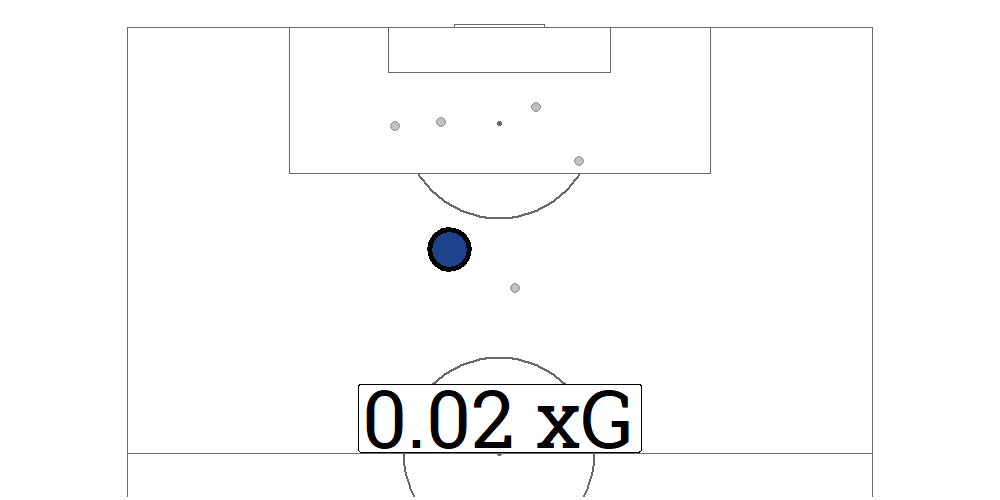

0.12932284

Open Play

Right Foot

Ball Recovery

52

Liverpool

Mohamed Salah

Blocked Shot

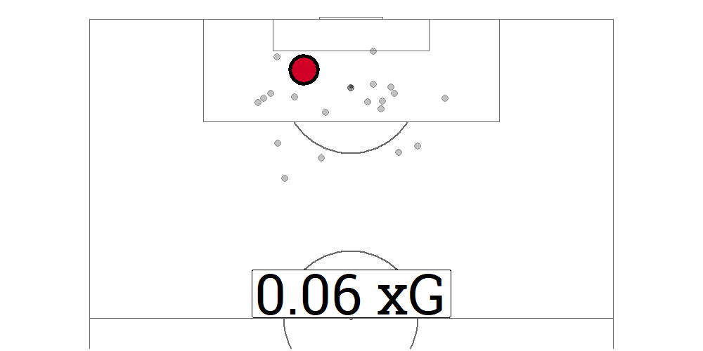

1.85909026

From Corner

Right Foot

Trent Alexander-Arnold

Cross

52

Liverpool

Virgil van Dijk

Missed Shot

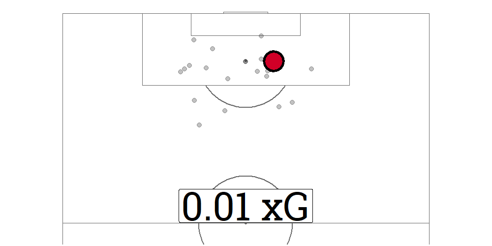

1.87200025

From Corner

Head

Trent Alexander-Arnold

Aerial

59

Liverpool

Mohamed Salah

Blocked Shot

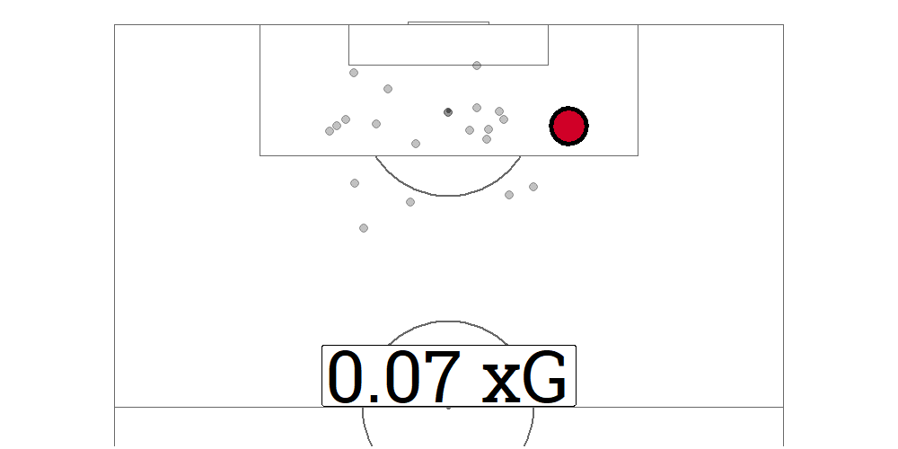

1.94343354

Open Play

Left Foot

Georginio Wijnaldum

Ball Recovery

61

Liverpool

Sadio Mané

Missed Shot

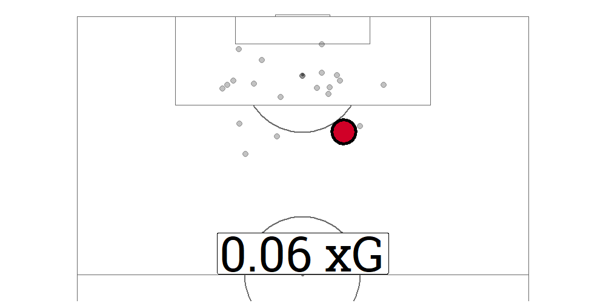

1.99957902

Open Play

Right Foot

Mohamed Salah

Pass

65

Leeds

Mateusz Klich

GOAL ⚽

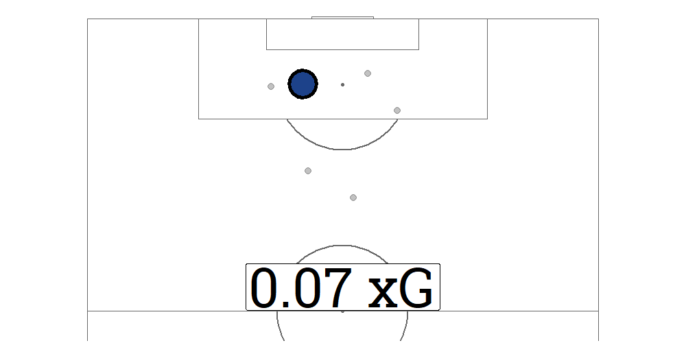

0.20254225

Open Play

Right Foot

Hélder Costa

Cross

67

Liverpool

Sadio Mané

Blocked Shot

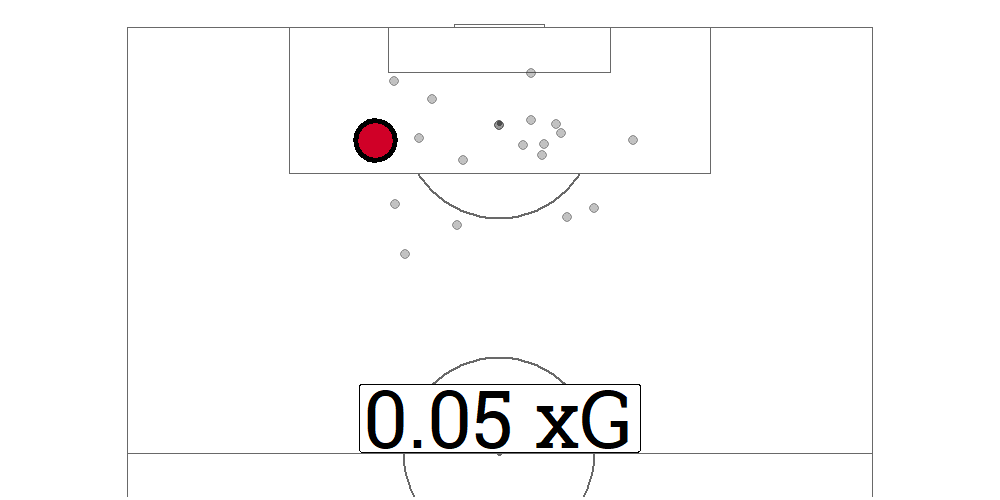

2.04657337

Open Play

Right Foot

Mohamed Salah

Pass

70

Liverpool

Sadio Mané

Blocked Shot

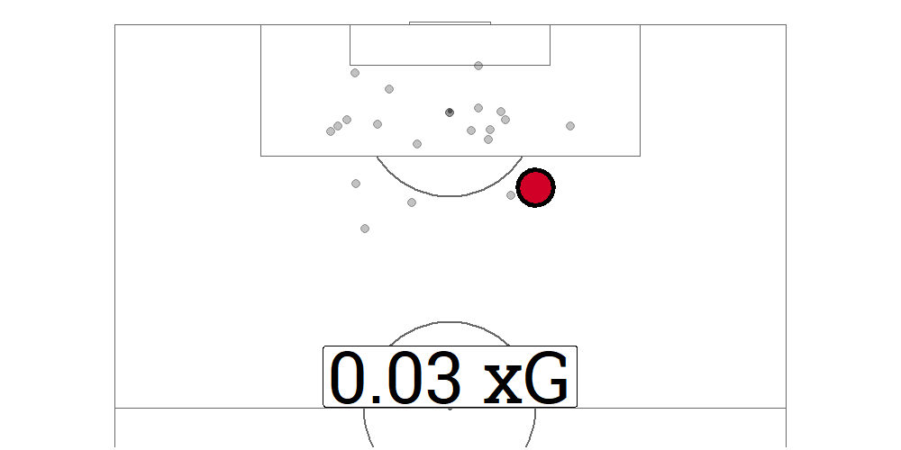

2.07211949

Open Play

Right Foot

Mohamed Salah

Take On

70

Liverpool

Mohamed Salah

Missed Shot

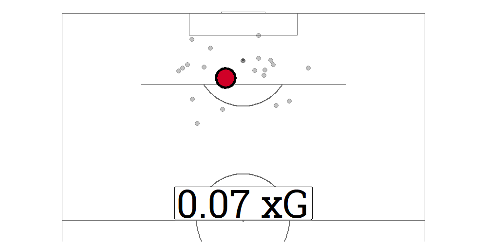

2.13769294

Open Play

Right Foot

75

Leeds

Kalvin Phillips

Missed Shot

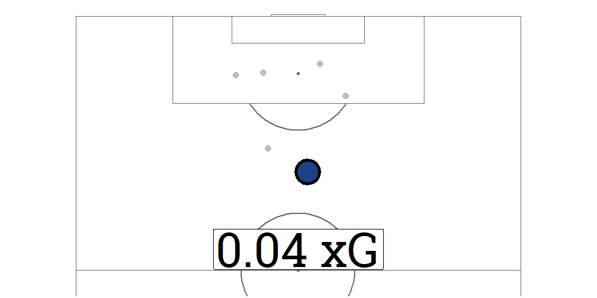

0.23844098

From Free Kick

Right Foot

77

Liverpool

Georginio Wijnaldum

Blocked Shot

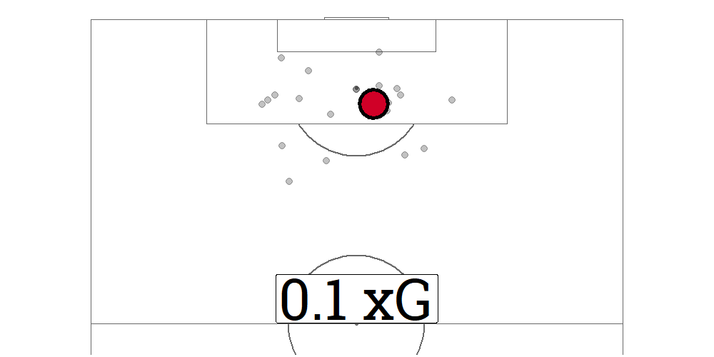

2.24154987

Open Play

Right Foot

Mohamed Salah

Pass

79

Liverpool

Mohamed Salah

Blocked Shot

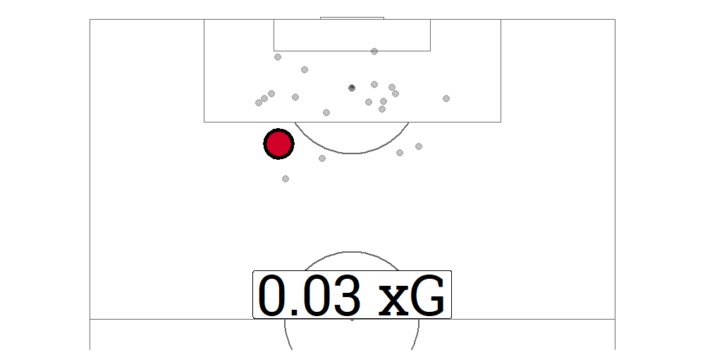

2.27220773

Open Play

Left Foot

Curtis Jones

Pass

84

Liverpool

Roberto Firmino

Blocked Shot

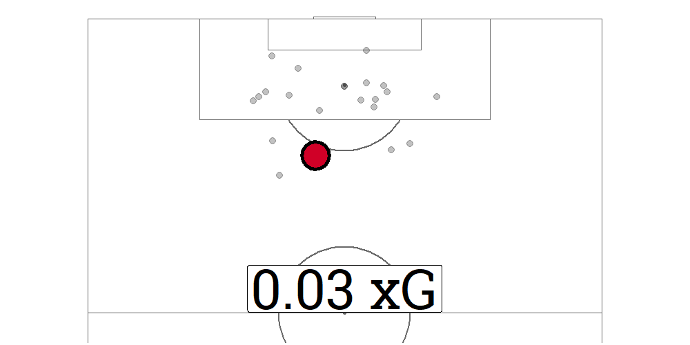

2.29760938

Open Play

Left Foot

86

Liverpool

Roberto Firmino

Blocked Shot

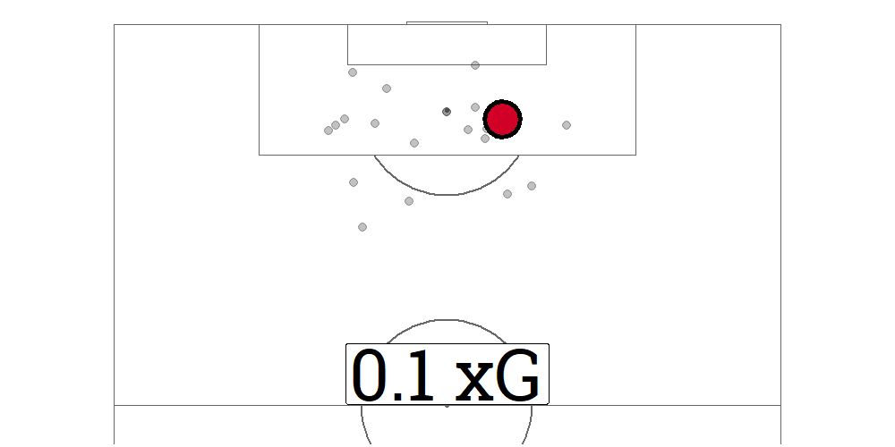

2.40236989

Open Play

Right Foot

Sadio Mané

Pass

87

Liverpool

Mohamed Salah

GOAL ⚽

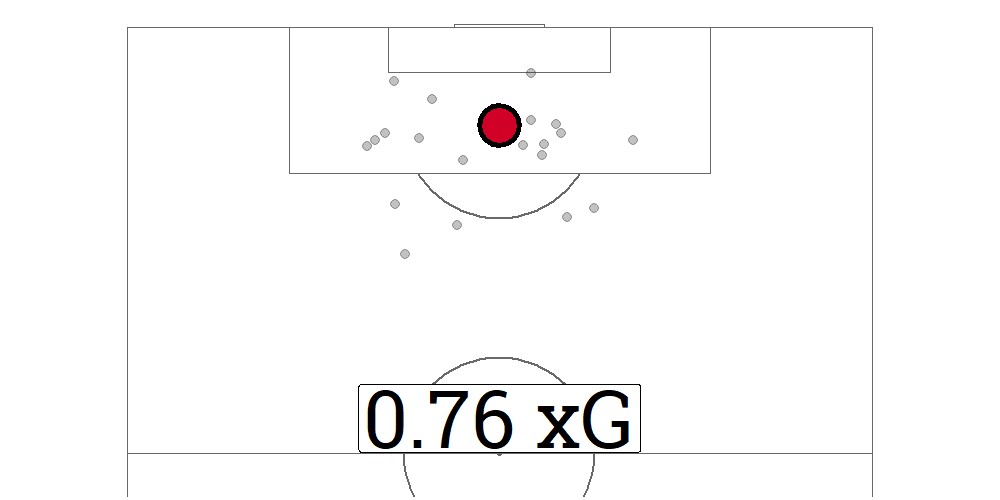

3.16353873

Penalty

Left Foot

90

Leeds

Robin Koch

Blocked Shot

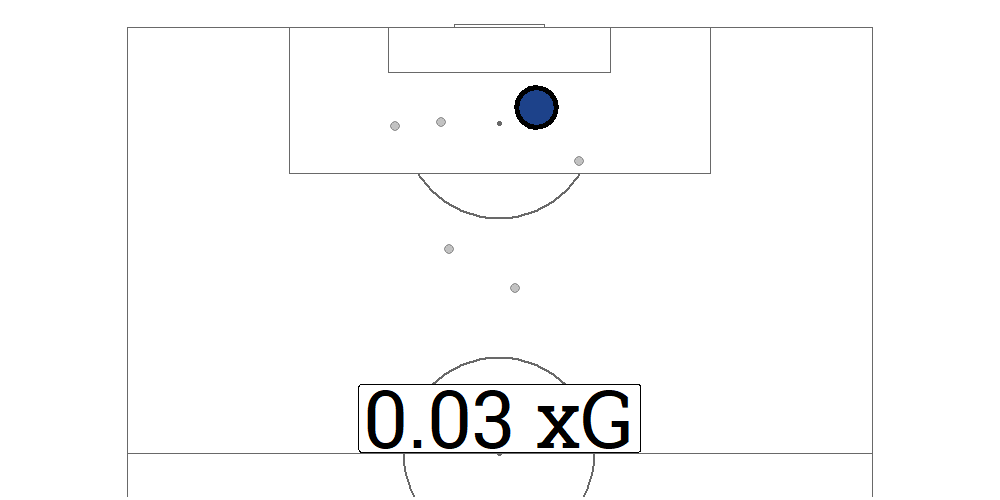

0.26981325

Open Play

Head

Kalvin Phillips

Aerial

**Table**: Ryo Nakagawara (**Twitter**: @R_by_Ryo) | **Data**: understat